# Midterm: Ice Cream

Alonso Romero, Russ Ballard

2024-03-25

# The Ice Cream Dataset

Our project uses an Ice Cream dataset that was retrieved from Kaggle from the following website: “https://www.kaggle.com/datasets/tysonpo/ice-cream-dataset/data”. The dataset contains a product and review datasets for 4 brands of ice cream, Ben & Jerry’s, Häagen-Dazs, Talenti, and Breyers. For the purposes of this project, we will be using a combined dataset provided by the author that combines all the products and reviews of all brands into their respective csv file.

```r
brandcolorpath <- file.path(projwd, datadir, "processing/brandcolors.csv")
brandcolordf <- data.frame(read.csv(brandcolorpath,
                           header=TRUE,
                           sep=",",
                           quote="\"",
                           colClasses=c("brand"="character",
                                        "color"="character",
                                        "fill"="character")))

brandcolordf
```

A metadata table containing color choices for the different brands has been created, this abstraction can be used for setting colors in the subsequent visualizations for standardizaiton and ease of implementation.

```r
prodcombpath <- file.path(outpath, "combined/products.csv")
products <- data.frame(read.csv(prodcombpath,
                            header=TRUE,
                            sep=",",
                            quote="\"",
                            colClasses=c("brand"="factor",
                                          "key"="character",
                                          "name"="character",
                                          "subhead"="character",
                                          "description"="character",
                                          "rating"="numeric",
                                          "rating_count"="numeric",
                                          "ingredients"="character")))
```

```r
reviewpath <- file.path(outpath, "combined/reviews.csv")
reviews <- data.frame(read.csv(reviewpath,
                            header=TRUE,
                            sep=",",
                            quote="\"",
                            na.strings=c("","NA"),
                            colClasses=c("brand"="factor",
                                          "key"="character",
                                          "author"="character",
                                          "date"="character",
                                          "stars"="numeric",
                                          "title"="character",
                                          "helpful_yes"="numeric",
                                          "helpful_no"="character",
                                          "text"="character",
                                          "taste"="numeric",
                                          "ingredients"="numeric",
                                          "texture"="character",
                                          "likes"="character")))

reviews$date <- as.Date(reviews$date,'%Y-%m-%d')
```

```r
nrow_products <- nrow(products)
nrow_reviews <- nrow(reviews)
```

The combined product dataset contains 241 data points, and the combined reviews dataset contains 21674 data points.

For the `products.csv` file, the variables in the dataset are:

- `brand`: brand keyword that categorizes each product to its respective brand
- `key`: the primary key that contains a numerical value and the brand keyword
- `name`: the product name
- `subhead`: simple description of the product (used for Ben & Jerry’s products only)
- `description`: detailed description of the product
- `rating`: a star rating scale with a range of 1.0 to 5.0
- `rating_count`: amount of ratings for the product
- `ingredients`: ingredient list of the product

For the `reviews.csv` file, the variables in the dataset are:

- `brand`: brand keyword that categorizes each product to its respective brand
- `key`: foreign key that matches to key in `products.csv`
- `author`: the username of the reviewer
- `date`: date that review was posted
- `stars`: reviewer rating of the product
- `title`: reviewer-created title of their review
- `helpful_yes`: amount of users that found the review helpful
- `helpful_no`: amount of users that found the review not helpful
- `text`: the text-based review
- `taste`: reviewer rating of product taste in a range of 1.0 to 5.0 (For Häagen-Dazs products only)
- `ingredients`: reviewer rating of product ingredients in a range of 1.0 to 5.0 (For Häagen-Dazs products only)
- `texture`: reviewer rating of product texture in a range of 1.0 to 5.0 (For Häagen-Dazs products only)
- `likes`: reviewer likes from a preset list to choose from (For Häagen-Dazs products only)

Regarding the dataset, there are important considerations that the author provides for users. First, “the collection of reviews on the brand websites may not be representative of overall opinion, i.e. there may be review censoring or presence of fake reviews meant to help/harm the image of the brand” (Pond, 2020). In order to combat this, the author, “intentionally chose brands that host some negative reviews on their website” (Pond, 2020). Next, the author acknowledges the parent companies of each of the brands. “Ben & Jerry’s, Breyers, and Talenti are all owned by Uniever. Häagen-Dazs is owned by Froneri” (Pond, 2020). It is also important to note that, “Talenti is distinguished from the other brands as they produce gelato” (Pond, 2020).

```r
products$HAS_VANILLA <- as.factor(as.integer(grepl(pattern = "VANILLA", x = products$Ingredients)))
products$HAS_ORGANIC <- as.factor(as.integer(grepl(pattern = "ORGANIC", x = products$Ingredients)))
products$HAS_CARAMEL <- as.factor(as.integer(grepl(pattern = "CARAMEL", x = products$Ingredients)))

fruitvec <- c("RASPBERR","CHERR","BLUEBERR","BANANA")
products$HAS_FRUIT <- as.factor(as.integer(grepl(pattern=paste(fruitvec,collapse="|"), x=products$Ingredients)))

chocvec <- c("CHOCOLAT","COCO")
products$HAS_CHOCOLATE <- as.factor(as.integer(grepl(pattern=paste(chocvec,collapse="|"), x=products$Ingredients)))

products$IS_BAR <- as.factor(as.integer(grepl(pattern = "BAR", x = products$ProductName) |
                                grepl(pattern = "BAR", x = products$Subhead)))
```

Using `grepl` we are able to implement regex matching to create additional binary indicator fields for ingredients in the `products` dataframe.

The additional fields:

This categorization and string parsing would be a key part of any clustering analysis performed on the data and there is much to be gleaned from additional analysis on the `Ingredients` field, though this is beyond the scope of this report.

```r
productreview <- left_join(reviews,
                           products %>% select(ProductID,
                                                 HAS_CARAMEL,
                                                 HAS_CHOCOLATE,
                                                 HAS_FRUIT,
                                                 HAS_VANILLA,
                                                 HAS_ORGANIC,
                                                 IS_BAR),
                           by="ProductID", multiple="all")
```

```r
xkablesummary(products, title = "Summary of the products dataset")
```

Summary of the products dataset

|  | Brand | ProductID | ProductName | Subhead | ProductDescription | Rating | RatingCount | Ingredients | HAS_VANILLA | HAS_ORGANIC | HAS_CARAMEL | HAS_FRUIT | HAS_CHOCOLATE | IS_BAR |
| --- | --- | --- | --- | --- | --- | --- | --- | --- | --- | --- | --- | --- | --- | --- |
| Min | bj :57 | Length:241 | Length:241 | Length:241 | Length:241 | Min. :1.20 | Min. : 2 | Length:241 | 0:111 | 0:237 | 0:217 | 0:218 | 0: 53 | 0:240 |
| Q1 | breyers:69 | Class :character | Class :character | Class :character | Class :character | 1st Qu.:4.00 | 1st Qu.: 28 | Class :character | 1:130 | 1: 4 | 1: 24 | 1: 23 | 1:188 | 1: 1 |
| Median | hd :70 | Mode :character | Mode :character | Mode :character | Mode :character | Median :4.40 | Median : 59 | Mode :character | NA | NA | NA | NA | NA | NA |
| Mean | talenti:45 | NA | NA | NA | NA | Mean :4.22 | Mean : 90 | NA | NA | NA | NA | NA | NA | NA |
| Q3 | NA | NA | NA | NA | NA | 3rd Qu.:4.70 | 3rd Qu.:112 | NA | NA | NA | NA | NA | NA | NA |
| Max | NA | NA | NA | NA | NA | Max. :5.00 | Max. :983 | NA | NA | NA | NA | NA | NA | NA |

```r
xkablesummary(reviews, title = "Summary of the reviews dataset")
```

Summary of the reviews dataset

|  | Brand | ProductID | Username | Date | Stars | Title | Helpful | Not Helpful | Review | Taste | Ingredients | Texture | Likes |
| --- | --- | --- | --- | --- | --- | --- | --- | --- | --- | --- | --- | --- | --- |
| Min | bj :7943 | Length:21674 | Length:21674 | Min. :2015-10-27 | Min. :1.00 | Length:21674 | Min. : 0 | Length:21674 | Length:21674 | Min. :1 | Min. :1 | Length:21674 | Length:21674 |
| Q1 | breyers:5007 | Class :character | Class :character | 1st Qu.:2018-05-17 | 1st Qu.:4.00 | Class :character | 1st Qu.: 0 | Class :character | Class :character | 1st Qu.:4 | 1st Qu.:4 | Class :character | Class :character |
| Median | hd :4655 | Mode :character | Mode :character | Median :2019-04-03 | Median :5.00 | Mode :character | Median : 0 | Mode :character | Mode :character | Median :5 | Median :5 | Mode :character | Mode :character |
| Mean | talenti:4069 | NA | NA | Mean :2019-02-17 | Mean :4.22 | NA | Mean : 1 | NA | NA | Mean :4 | Mean :4 | NA | NA |
| Q3 | NA | NA | NA | 3rd Qu.:2020-04-02 | 3rd Qu.:5.00 | NA | 3rd Qu.: 1 | NA | NA | 3rd Qu.:5 | 3rd Qu.:5 | NA | NA |
| Max | NA | NA | NA | Max. :2020-10-04 | Max. :5.00 | NA | Max. :421 | NA | NA | Max. :5 | Max. :5 | NA | NA |
| NA | NA | NA | NA | NA | NA | NA | NA | NA | NA | NA’s :17409 | NA’s :17409 | NA | NA |

# Exploratory Data Analysis

#### For this project we will be addressing the following questions: Are there differences amongst the different brands in terms of ratings or discernable themes in the product reviews? And is there independence between ice cream ingredient content and review rating?

We will explore the Ice Cream dataset by creating graphs, performing tests, and finding the measures of central tendency and variation. First, we’ll look at the overall dataset, and then the individual datasets of each of the four brands.

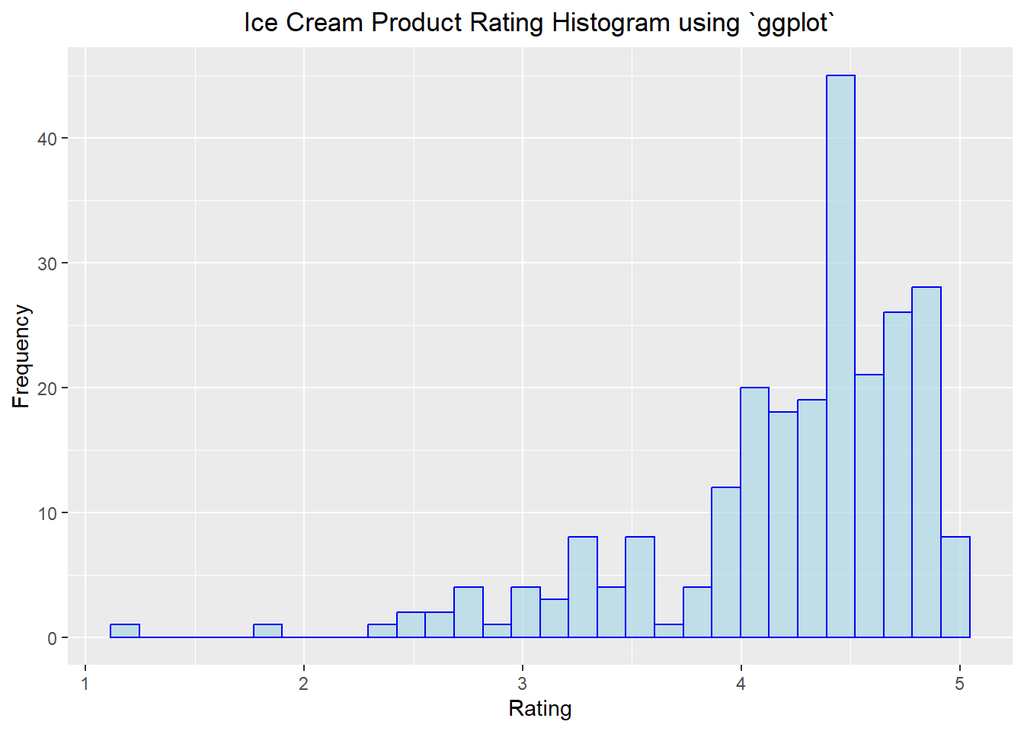

```r
library(ggplot2)
ggplot(data=products, aes(Rating)) +
  geom_histogram(col='blue', fill='lightblue', alpha=0.7) +
    labs(x="Rating", y="Frequency") +
    labs(title="Ice Cream Product Rating Histogram using `ggplot`") +
    theme(plot.title = element_text(hjust = 0.5))
```

This histogram shows the overall ratings of all ice-cream products across all 4 brands of ice-cream. We can see that there is a high frequency of ratings within the 4 - 5 star range. Based on the histogram above, we can see a left skewed distribution. To further test the skewness, we will perform a QQ plot.

```r
sd.ratings <- sd(products$Rating)
mean.ratings <- mean(products$Rating)
sd.ratings
mean.ratings
```

The mean of the data above is 4.223 and the standard deviation is 0.62

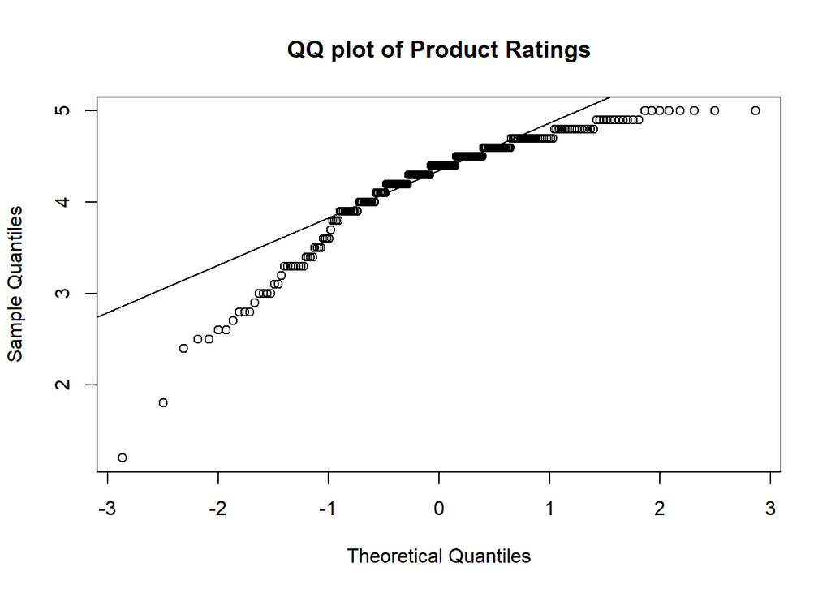

```r
qqnorm(products$Rating, main="QQ plot of Product Ratings")
qqline(products$Rating)
```

Based on the Q-Q plot above, we see that the graph is displaying a left skew as most of the data points are within the third to fifth sample quantile. Therefore this graph displays that the dataset does not present a normal distribution. To further test for normality, the Shapiro-Wilk test is conducted below.

```r
shapiro.test(products$Rating)
```

```
##
##  Shapiro-Wilk normality test
##
## data:  products$Rating
## W = 0.9, p-value = 9e-14
```

For the Shapiro-Wilk test, we are given the following hypotheses:

- `Null Hypothesis`: The sample comes from a normally distributed population
- `Alternative Hypothesis`: The sample does not come from a normally distributed population

Based on the results of the test, the p-value is less than the significance level of 0.05, which means that we reject the null hypothesis and conclude that the data from the sample does not come from a normally distributed population.

#### Measures of Central Tendency

With the combined dataset, we will calculate the mean, median, and mode for this dataset.

- `Mean`: 4.223
- `Median`: 4.4
- `Mode`: 4.7

Based on these results, this further proves that the data is left skewed since the mean is the lowest value followed by the median and the the mode being the highest value.

#### Measures of Variation

With the combined dataset, we will calculate the range, mean deviation, standard deviation, and variance.

- `Range`: 1.2, 5
- `Mean Deviation`: 0.46
- `Standard Deviation`: 0.62
- `Variance`: 0.385

```r
z4rating <- (4 - mean.ratings)/sd.ratings
```

We will generate a z-score for a rating of 4 in our distribution.

By taking the value of 4 and subtracting it with the mean 4.223 and dividing everything by the standard deviation of 0.62, we get the z score of -0.36.

Based on this result, we can determine that a rating of 4 lays within the range of the mean and one standard deviation to the left in our distribution.

```r
pnorm.rating <- pnorm(z4rating)
```

By taking the `pnorm()` function, 0.359 is the probability that a rating of `4` is under the distribution.

```r
loadPkg("Hmisc")
describe(products$Rating)
```

```
## products$Rating
##        n  missing distinct     Info     Mean      Gmd      .05      .10
##      241        0       29    0.995    4.223   0.6426      3.0      3.3
##      .25      .50      .75      .90      .95
##      4.0      4.4      4.7      4.8      4.9
##
## lowest : 1.2 1.8 2.4 2.5 2.6, highest: 4.6 4.7 4.8 4.9 5
```

Describe the overall data by using the the `describe()` function to highlight the ratings column.

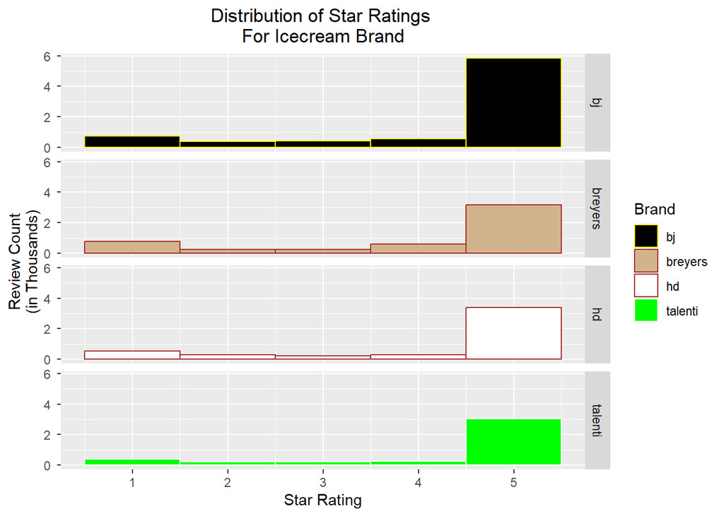

```r
ggplot(data = productreview, aes (x = Stars, color=Brand, fill = Brand)) +
  geom_histogram(binwidth=1,boundary=-.5) +
  labs(title="Distribution of Star Ratings \nFor Icecream Brand",
   x="Star Rating",
   y="Review Count\n(in Thousands)") +
  scale_y_continuous(labels = unit_format(unit = "", scale = 1e-3)) +
  facet_grid(Brand ~ .) +
  scale_fill_manual(values=brandcolordf$fill) +
  scale_colour_manual(values=brandcolordf$color) +
  theme(plot.title = element_text(hjust = 0.5))
```

A faceted histogram of star ratings for product reviews. We can observe that the data is as described in the brief and highly clustered around 5’s.

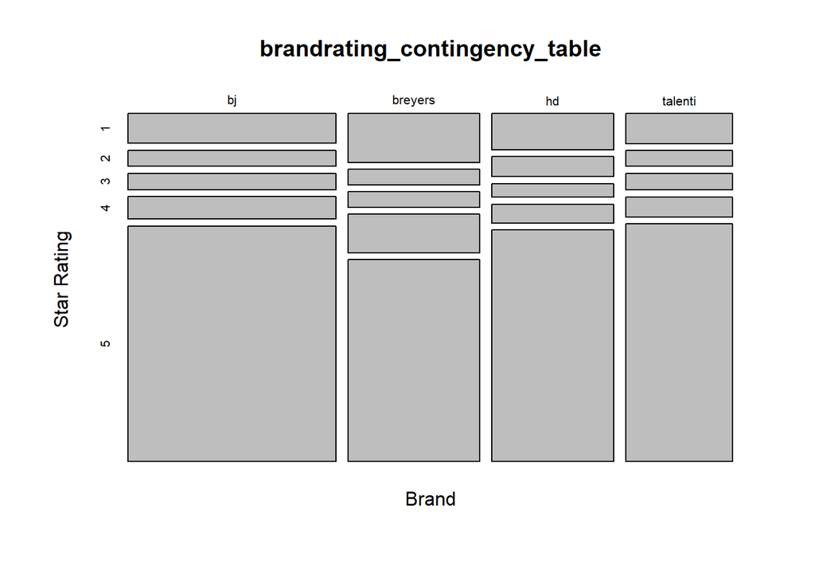

```r
brandrating_contingency_table<-table(productreview$Brand,productreview$Stars, dnn=c("Brand", "Star Rating"))

brandrating_contingency_table
prop.table(brandrating_contingency_table,margin=1)

mosaicplot(brandrating_contingency_table)
```

Above is the contingency table for the brand product-reviews. We can see that the proportions are as described in the histogram, largely 5’s for all brands. Interestingly, Breyer’s appears to have a larger proportion of 1’s than the other groups.

### Ben & Jerry’s

Ben & Jerry’s mission for their products is to “make, distribute, and sell the finest-quality ice cream and euphoric concoctions with a continued commitment to incorporating wholesome, natural ingredients and promoting business practices that respect the Earth and the Environment” (“Our Values, Activism, and Mission”, n.d.)

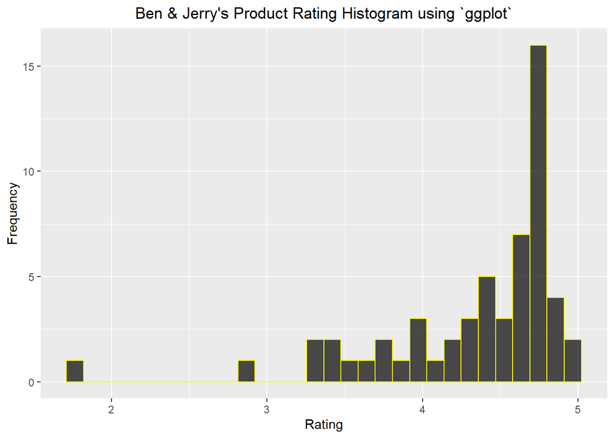

```r
bj_data <- subset(products, Brand == "bj")

bjcol <- brandcolordf$color[brandcolordf$brand=="bj"]
bjfill <- brandcolordf$fill[brandcolordf$brand=="bj"]

ggplot(bj_data, aes(Rating)) +
  geom_histogram(col=paste(bjcol), fill=paste(bjfill), alpha=0.7) +
  labs(x="Rating", y="Frequency") +
  labs(title="Ben & Jerry's Product Rating Histogram using `ggplot`") +
  theme(plot.title = element_text(hjust = 0.5))
```

```r
mean.bjratings <- mean(bj_data$Rating)
sd.bjratings <- sd(bj_data$Rating)
```

Looking at the graph, it is very similar to the histogram of all four brands combined, where it shows a left skewed distribution. The mean of the data above is 4.332 and the standard deviation is 0.6

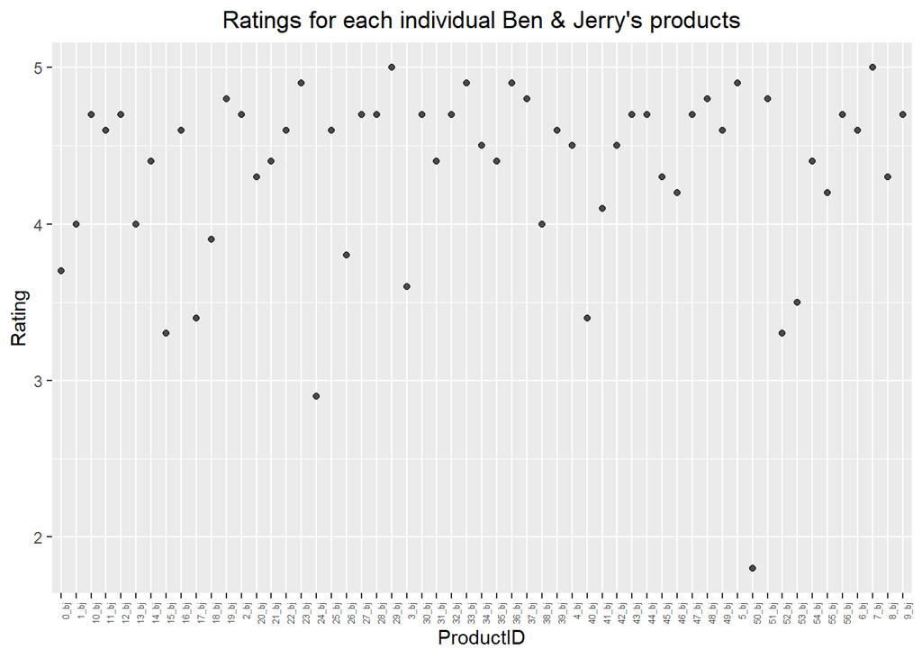

```r
#Color and fill are inverted here for readability
ggplot(bj_data, aes(x=ProductID, y=Rating)) +
  geom_point(col=paste(bjfill), fill=paste(bjfill), alpha=0.7) +
  labs(x="ProductID", y='Rating') +
  labs(title="Ratings for each individual Ben & Jerry's products") +
  theme(axis.text.x = element_text(angle=90, hjust=1, size = 5)) +
  theme(plot.title = element_text(hjust = 0.5))
```

Here is a chart depicting average rating for each Ben and Jerry’s product. This data could be further parsed to give indication of ingredient contents.

```r
# Finding the highest rated products
max_rating_index <- which(bj_data$Rating == max(bj_data$Rating))
max_productname <- bj_data$ProductName[max_rating_index]

# Finding the lowest rated products
min_rating_index <- which(bj_data$Rating == min(bj_data$Rating))
min_productname <- bj_data$ProductName[min_rating_index]
```

```
## [1] "This is my Favorite Ben & Jerrys Flavor ever, I wish it was easier to find. so many pB cups !! #LOVE that !! I really hope they make it permanent, because their is not very many other options for banana lovers. (I Hate the toppings in Chunky Monkey (◕︿◕✿)) would love if they added fudge brow…
## [2] "I'm so glad this flavor exists, it's my new favorite! Chocolate, PB, and banana is such a good combo, I order smoothies and milkshakes in that combo too."
## [3] "It’s like chunky monkey but with peanut butter cups instead of nuts!"
## [4] "This is the best Ben & Jerry's I've ever had! I can no longer eat nuts so the peanut butter cups are the best alternative to Chubby Hubby. I hope this flavor is available forever!"
## [5] "Bought this on a whim and it's the best B&J flavor of them all."
## [6] "My local store sold out completely of this flavor, no word when it’s coming back. :( I love it. The banana so good. It’s the better version of chunky monkey! The cups are perfect!"
```

Above we see the first 6 reviews of Ben & Jerry’s Chocolate Peanut Butter Split ice cream. Based from these reviews, customers absolutely love this flavor as it is unique by having banana and also having peanut butter cups in the ice cream.

```
## [1] "This is my favorite Icecream in the whole wide world. POINT BLANK PERIOD. I drive 5 miles to the closest store that carries it atleast 1 a week which is a good thing as if it were closer is probably eat it everyday. Amazing job on this one guys!"
## [2] "It's been a while since I've bought this ice cream because I can't find it in my local grocery store but I love this flavor so much! I ate two pints in one sitting! My doctor says I need to stop buying Ben and Jerrys because of my diabetes but I can't stop! Aaahhh! I love this ice cream so m…
## [3] "Literally my favorite ice cream out of all of the ice cream I've eaten in the world. Sometimes it's hard to find at certain stores, but I'll climb through a freezer door to search for it. #NoShame"
## [4] "This is my go to flavor whenever I buy Ben & Jerrys! I love how big the chocolate cookie chunks are!"
## [5] "This has always been my favorite but the last 3 pints I have bought have had almost no chocolate cookie chunks! This is very upsetting as this is my favorite ice cream and my favorite park is the cookie chunks. I instead have been left with mint ice cream with a few spattering of what looks …
## [6] "I really like this flavor, it is super awesome! For real, my favorite."
```

Based from the graph, the lowest rated Ben & Jerry’s products: Chocolate Chip Cookie Dough Core

```
## [1] "I love Ben & Jerry’s which is why I am writing this review - I feel they would care to know how disappointing this flavor is! The core in the pint I purchased was super small, making it a total disappointment. I kept digging hoping it would get bigger and it just ended up almost disappearing…
## [2] "i am so upset that this didnt meet any of my expectations. the cookie “dough” is just grainy sugar! not to mention i get more cookie dough out of a regular ben & jerry’s cookie dough or even half baked than what i got in this. this needs a reboot! please consider making the core out of your …
## [3] "I was so excited for this because I love cookie dough but there’s never enough. I thought the core would look how it’s advertised. Spoiler alert: It didn’t. Barely any dough. Didn’t go all the way through consistently and couldn’t even be in the center. Also the dough didn’t taste great? Idk…
## [4] "Even after reading all the reviews that said it wasn't good I still went and bought it anyways because it looked & sounded so good, but sadly the reviews are right. most of the time with cookie dough ice cream I wish there was more cookie dough (i thought this would be the super cookie-dough…
## [5] "I preordered this as soon as they announced that it was available in the online store. I was so excited to dig in but while the ice cream is delicious, the cookie dough core is terrible. Rock hard, gritty, sandy, and very inconsistent in size from the top of the pint to the bottom. I hate ha…
## [6] "I waited and waited for this to be available at my local store. Yuck. Hard, grainy cookie dough core? This is nothing like cookie dough. Don’t be fooled, the cookie dough core is SMALL! I’m a Ben and Jerry’s fan, but you lost me here. So disappointed!"
```

Above we see the first 6 reviews of Ben & Jerry’s Chocolate Chip Cookie Dough Core. Customers were disappointed as the cookie dough core was either lacking or completely absent. When there was a a bit of dough in the core, it did not meet customers’ expectations as many claim that it does not taste like cookie dough.

#### Measures of Central Tendency

With the Ben & Jerry’s data subset, we will calculate the mean, median, and mode for this dataset.

- `Mean`: 4.332
- `Median`: 4.6
- `Mode`: 4.7

The measures of central tendency shows us that the average rating is 4.332, a median rating of 4.6, with a rating of 4.7 appearing most often from reviewers. Continuing on the trend from the overall ice cream flavors, the measures of central tendency for Ben & Jerry’s data display a left skewed distribution since mean < median < mode.

#### Measures of Variation

With the Ben & Jerry’s data subset, we will calculate the range, mean deviation, standard deviation, and variance.

- `Range`: 1.8, 5
- `Mean Deviation`: 0.443
- `Standard Deviation`: 0.6
- `Variance`: 0.36

With the Ben & Jerry’s dataset, the data ranges 3.2 data points from the lowest point to the highest point. The mean deviation here shows us that on average, each value in the dataset is about 0.443 points away from the mean. The standard deviation shows us that the data is dispersed 0.6 points in relation to the mean. The variance shows that each data point is about 0.36 points away from the mean and other data points in the dataset.

### Häagen-Dazs

Since 1960, Häagen Dazs kept their mission simple, “source the finest ingredients and transform them into the most luxurious ice cream. Because [they] believe that luxury is found wherever you are - in moments large and small” (“About Us”, n.d.).

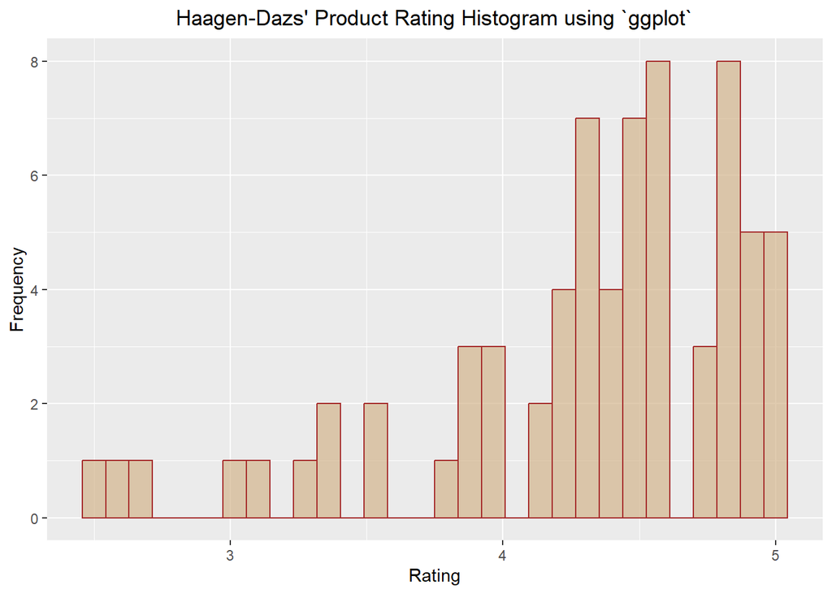

```r
hd_data <- subset(products, Brand == "hd")

hdcol <- brandcolordf$color[brandcolordf$brand=="hd"]
hdfill <-brandcolordf$fill[brandcolordf$brand=="hd"]

ggplot(hd_data, aes(Rating)) +
  geom_histogram(col=paste(hdcol), fill=paste(hdfill), alpha=0.7) +
  labs(x="Rating", y="Frequency") +
  labs(title="Haagen-Dazs' Product Rating Histogram using `ggplot`") +
  theme(plot.title = element_text(hjust = 0.5))
```

```r
mean.hdratings <- mean(hd_data$Rating)
sd.hdratings <- sd(hd_data$Rating)
```

From the graph, we can see that data is more concentrated equally to the right of the graph, which the data also presents a left skewed distribution. The mean of the data above is 4.307 and the standard deviation is 0.597

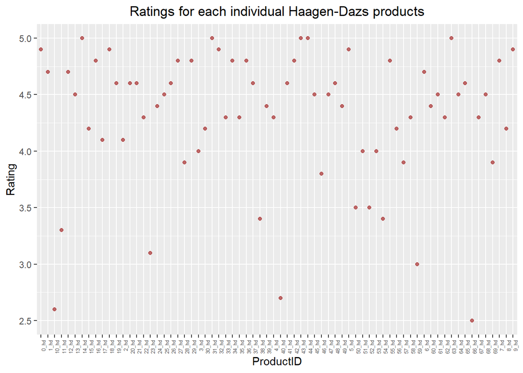

```r
ggplot(hd_data, aes(x=ProductID, y=Rating)) +
  geom_point(col=paste(hdcol), fill=paste(hdfill), alpha=0.7) +
  labs(x="ProductID", y='Rating') +
  labs(title="Ratings for each individual Haagen-Dazs products") +
  theme(axis.text.x = element_text(angle=90, hjust=1, size = 5)) +
  theme(plot.title = element_text(hjust = 0.5))
```

```r
# Finding the highest rated products
max_rating_index <- which(hd_data$Rating == max(hd_data$Rating))
max_productname <- hd_data$ProductName[max_rating_index]

# Finding the lowest rated products
min_rating_index <- which(hd_data$Rating == min(hd_data$Rating))
min_productname <- hd_data$ProductName[min_rating_index]
```

Based from the graph, the highest rated Häagen-Dazs products: Chocolate Fudge Non-Dairy Bar, Honey Salted Caramel Almond Ice Cream, Peppermint Bark Ice Cream, Peppermint Bark Ice Cream Bar, Vanilla Caramel White Chocolate TRIO CRISPY LAYERS

```
## [1] "This is absolutely the best ice cream I have had in two years! It has been that long since I have been lactose intolerant, allergic to almonds and sensitive to soy and coconut milk. Most dairy free ice creams contain one of my allergens/sensitivities (soy and coconut oil in this, but not mil…
## [2] "I am so grateful for these. They taste fantastic, and my allergic kids have eaten their first ice cream bars EVER! My 13 year old has to sit at lunch everyday and watch kids eat ice cream while he can't. This is just the best day for him. My 11 year old had his first last week, and I cried w…
## [3] "I wandered down the frozen treat aisle dejected, lactose intolerant and disappointed. Then... I saw it, non dairy, chocolate, and it looked so satisfying. I tossed it in my cart and hurried home so it wouldn’t melt. The taste was amazing! Soft, creamy, and unlike other non dairy themed produ…
## [4] "I actually had to come on here and triple check there was no milk in them. Both my son and myself are allergic to milk but love chocolate. I just wish it was sold in larger quantities and I hope it doesnt get discontinued like the chocolate sorbet."
## [5] "Much to my chagrin, 15 years ago my body begin having trouble digesting dairy products. I was so sad because I loved ice cream, milkshakes, etc. However, as more companies started investing in and producing non-dairy and vegan products in recent years, I slowly begin working my way through t…
## [6] "I'm a teenager and I've been vegan for 10 months now. I've had plenty of vegan ice creams but they usually have some almond milk or coconut milk taste that is different from real ice cream. It was never a big bother for me but I recently bought this and it reminds me of real ice cream. I'm t…
```

Above are the first 6 reviews of Häagen-Dazs’ Chocolate Fudge Non-Dairy Bar. Customers that are lactose intolerant absolutely love this product. Having tried other non-dairy products from other brands, customers rate this product above all as the flavor tastes amazing for a non-dairy product.

```
## [1] "This is simply the best Ice Cream ever invented! It is so good that not only will you fall in love and get addicted to the flavor, but you will have dreams of a world made completely out of Honey Salted Caramel Almond, ice cream! There isn't enough words available in all the languages on the…
## [2] "OMG......My husband and I recently discovered this flavor and have developed a daily habit. Yes, that’s right, I said a DAILY habit. When our local supermarket sells out, we scour the city to find it. When eating this delicious concoction, each spoonful is like a experiencing this tasteful t…
## [3] "Picked this up a few days ago on a whim at my local Wal-mart. Figured it would be something different(love me some chocolate. But just feel the market can be so saturated with chocolate ice creams at times. Or includes chocolate pieces. So good to have a change on the shelf) to give a try. A…
## [4] "As usual, Haagen Daz creates something so incredible and so sinfully good, it's cost me a friendship. Currently training for some races and body building. I committed to our workout group (consisting of a strict diet plan)... until I ran into this. Put it this was, I've already eaten a total…
## [5] "For the past 2 years my go to Haagen Dazs flavor has been Pineapple Coconut...but I may have a new favorite. The only problem is, no one stocks it! Please start stocking this everywhere! I can find the 3oz minis but that just isn't enough!!!"
## [6] "I brought this by mistake and every since then its all I can think about eating. I brought 6 pints one day and I went back the next and it was all gone. My spirit was crushed. The way the flavors come together, the smooth caramel, the honey, the hint of salt, and the creamy vanilla....heaven…
```

Above are the first 6 reviews of Häagen-Dazs’ Honey Salted Caramel Almond Ice Cream. Customers absolutely love this flavor and considering it as their favorite flavor and eating multiple pints in one day.

```
## [1] "I love this ice cream. It’s smooth, creamy, minty and chocolate combo is what has me addicted to it. I’m actually online writing a review that’s how serious my obsession is with this ice cream. Also I need to locate other stores near me that has some left. The grocery store nearest to me sol…
## [2] "PLEASE PLEASE make this available all year round! it would be refreshing to have in the summertime, don't you think? YEAR ROUND PLEASE. this is fantastic and I hate to have to enjoy it for just a limited time"
## [3] "I feel like an addict trying to find this ice cream. It's so good but I don't have a Haagen Dazs near me. I've even tried to substitute it by buying talenti gelato ice cream that makes peppermint bark but it's not the same and the store that was carrying it now stopped a month ago. Lord I wi…
## [4] "had it for the first time yesterday, and now i'm on my second pint. I love it a whole lot. Couldn't worry about the calories when you got an ice cream this good. THIS FLAVOR IS PURE LOVE."
## [5] "This is my very favorite! Sad that I can only get it during the holidays. Please consider selling year round. It’s sooo good!"
## [6] "This flavor needs to be available all year! Why isn't it?"
```

Above are the first 6 reviews of Häagen-Dazs’ Peppermint Bark Ice Cream. Customers absolutely love this flavor. The only issue that was stated in the reviews is that this product is not available year-round, only in December.

```
## [1] "These are the most delicious, crunchy good ice cream bars ever! Unfortunately, they rarely appear in stores."
## [2] "My new favorite, but bummed they are for a limited time. Come on lets put them in the normal rotation"
## [3] "Crunchy tasty peppermint bark coating (dark chocolate!)."
## [4] "They are available in 3 pack. But others are available in 3 - 6 pack. We add our white chocolate covered in dark chocolate and our almonds."
## [5] "They are available in 3 pack. But others are available in 3 - 6 pack. But we made it by making white chocolate ice cream, making solid dark chocolate ice cream with almonds. Then we add mint."
## [6] "I found these at a store near by, but they only had them for about a month. They were wonderful and I wish I could find a place that has them."
```

Above are the first 6 reviews of Häagen-Dazs’ Peppermint Bark Ice Cream Bar. This product is the bar version of the Peppermint Bark Ice Cream above. Customers love that there are multiple bars, and complain on the product not being available year-round.

```
## [1] "This is hands down the most delicious ice cream I've ever tasted! The rich yet subtle ice cream flavors (vanilla & caramel) pair perfectly with the crisp thin white chocolate resulting in the perfect sophisticated and irresistibly sweet combination."
## [2] "Absolutely delicious creamy and smooth. Taste was rich and luscious. The vanilla was just the prefect balance of sweetness and creamy the salted Carmel layer was surprisingly smooth and chewy and tasted like a real classy Carmel. The crispy layer added a nice crunch. To the mix. Overall a de…
## [3] "Wow. I love this flavor so much! I was walking in Kroger shopping for my mom and I saw the picture but didn't think to get it. I called her later on before she got home and asked her to stop by and get me some cause it couldn't leave my mind. I am SO GLAD I did! It is so good! I've only had …
## [4] "I’m usually a chocolate kind of gal (milk & dark). I actually bought this ice cream for my husband because he loves white chocolate and caramel. I decided to taste it and I have literally been obsessed since. I once went to twelve different grocery stores in one day to try to find one that w…
## [5] "Hands down the best flavor of any ice cream. White chocolate is so hard to find in ice creams and this combination is to die for!! Wish I could eat this everyday."
## [6] "This combo is spectacular! I truly enjoyed the flavors of the vanilla and caramel ice cream. Then I get to the fun part which is the caramel sauce and white chocolate chips. This reminds of a less sweeter version of dulce de leche. I like that because the dulce is extremely sweet for my tast…
```

Above are the first 6 reviews of Häagen-Dazs’ Vanilla Caramel White Chocolate Trio Crispy Layers. Customers are obsessed with the flavor combination, the creamy texture, and are just overall satisfied with the product.

Based from the graph, the lowest rated Häagen-Dazs product: Vanilla Milk Chocolate Almond Ice Cream Bar

```
## [1] "I bought a box of the this a week ago and there was no issue with the overall taste. Then just a few days ago I bought another box this time around the box was different (I guess it was the birthday addition because that’s what was stated on the box. Anyway the taste of the ice cream was hor…
## [2] "I grew up eating Haagen Daz and it was always a treat for me. I haven't had it in a couple of years because I'm lactose intolerant and lactase pills don't work, but I was really craving that creamy, rich vanilla and think chocolate and crunchy almonds that I remember from my childhood in the…
## [3] "Got a big box from costco and from one week to the next, they had completely changed! It's not just the shape, which is a smaller rectangle compared to I guess the more triangular shape it used to be? The chocolate coating is thinner - I take one bite and the entire side of coating falls off…
## [4] "I am diabetic and cannot enjoy your product very often. Today the temp was 120 F and I had to have some Ice Cream and this product was one of my favorites. The size is much smaller. the creamy taste was gone. the milk chocolate coating was not the rich snappy coating of old. When I indulge I…
## [5] "I've been eating Haagen Dazs for more than 40 years. I rarely eat any other ice cream; my favorite is the milk chocolate with vanilla ice cream bar. I know for sure that the size of the bars is about half the size they were a few years ago. I joke with my husband about how, if the size conti…
## [6] "We always buy them from Costco, especially when they are $3 off. But last week the bars are smaller, and most of the almonds disappeared! OMG, it looks nothing like before, or the picture still show on the box! It also tastes different, the chocolate taste somehow is the same. The skimming o…
```

Above are the first 6 reviews of Häagen-Dazs’ Vanilla Milk Chocolate Almond Ice Cream Bar. The customers complained that the quality of the product not meeting their expectations. Others complained about the lack of almonds in the bar and a thinner layer of chocolate.

#### Measures of Central Tendency

With the Häagen Dazs data subset, we will calculate the mean, median, and mode for this dataset.

- `Mean`: 4.307
- `Median`: 4.5
- `Mode`: 4.6, 4.8

The measures of central tendency shows us that the average rating is 4.307, a median rating of 4.5, and with the ratings of 4.6 and 4.8 tied for being awarded the most often by reviewers. These values also show that the data displays a left skewed distribution.

#### Measures of Variation

With the Häagen Dazs data subset, we will calculate the range, mean deviation, standard deviation, and variance.

- `Range`: 2.5, 5
- `Mean Deviation`: 0.446
- `Standard Deviation`: 0.597
- `Variance`: 0.357

With the Häagen-Dazs dataset, the data ranges 2.5 data points from the lowest point to the highest point. The mean deviation here shows us that on average, each value in the dataset is about 0.446 points away from the mean. The standard deviation shosw us that the data is dispersed 0.597 points in relation to the mean. The variance shows that each data point is about 0.357 points away from the mean and other data points in the dataset.

### Talenti

Talenti strives to “travel the world over to source the highest quality ingredients. Whether it’s fragrant vanilla beans from Madagascar, or creamy mangos from Maharashta, [they] always start with real ingredients for the most authentic flavors” (“Our Process”, n.d.).

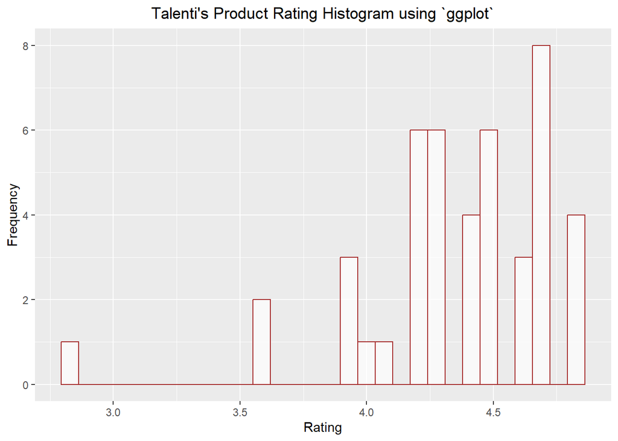

```r
talenti_data <- subset(products, Brand == "talenti")

talcol <- brandcolordf$color[brandcolordf$brand=="talenti"]
talfill <-brandcolordf$fill[brandcolordf$brand=="talenti"]

ggplot(talenti_data, aes(Rating)) +
  geom_histogram(col=paste(talcol), fill=paste(talfill), alpha=0.7) +
  labs(x="Rating", y="Frequency") +
  labs(title="Talenti's Product Rating Histogram using `ggplot`") +
  theme(plot.title = element_text(hjust = 0.5))
```

```r
mean.talratings <- mean(talenti_data$Rating)
sd.talratings <- sd(talenti_data$Rating)
```

From the graph, we can see that there are not as many products within the Talenti brand when compared to the other brands. We can also the graph displays a left-skewed distribution. The mean of the data above is 4.356 and the standard deviation is 0.387

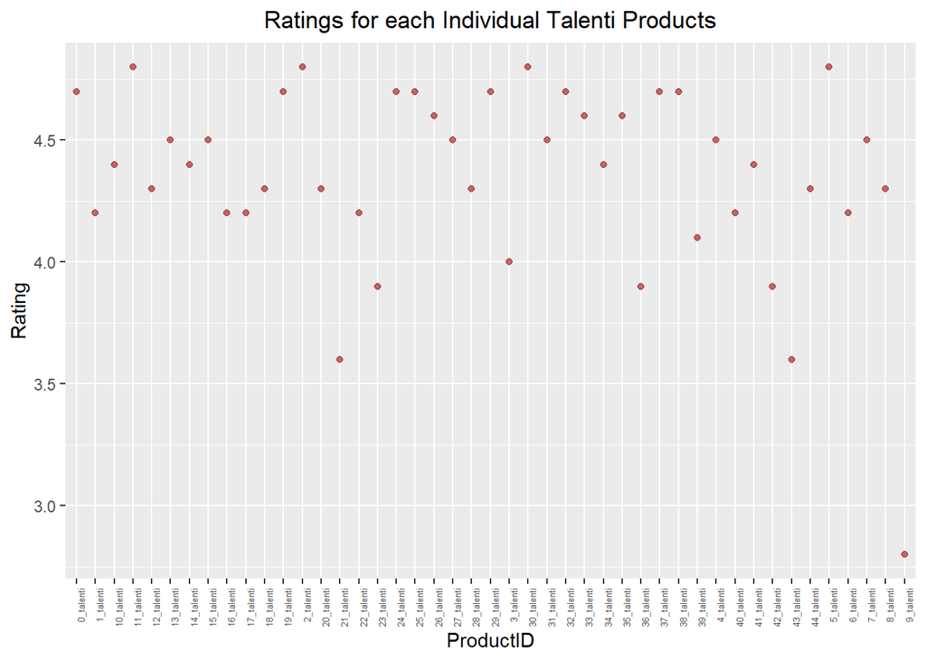

```r
ggplot(talenti_data, aes(x=ProductID, y=Rating)) +
  geom_point(col=paste(talcol), fill=paste(talfill), alpha=0.7) +
  labs(x="ProductID", y='Rating') +
  labs(title="Ratings for each Individual Talenti Products") +
  theme(axis.text.x = element_text(angle=90, hjust=1, size = 5)) +
  theme(plot.title = element_text(hjust = 0.5))
```

```r
# Finding the highest rated products
max_rating_index <- which(talenti_data$Rating == max(talenti_data$Rating))
max_productname <- talenti_data$ProductName[max_rating_index]

# Finding the lowest rated products
min_rating_index <- which(talenti_data$Rating == min(talenti_data$Rating))
min_productname <- talenti_data$ProductName[min_rating_index]
```

Based from the graph, the highest rated Talenti products: BELGIAN CHOCOLATE GELATO, CARAMEL APPLE PIE GELATO, COCONUT ALMOND CHOCOLATE GELATO, ORGANIC OAK-AGED VANILLA GELATO

```
## [1] "I'm typically more of a dark chocolate devotee, but this Belgium Milk Chocolate gelato is so rich and creamy, it has become my absolute favorite (and I eat a 1/2 pint at a sitting easily!) Thank You, Talenti!!"
## [2] "This was the first flavor of Talenti products that I tried and I have been buying Talenti's gelato and sorbetto ever since. This Belgium Chocolate is great . Smooth and tasty."
## [3] "I'm not a huge chocolate fan, but this is amazing. It's so smooth and creamy. First Talenti flavor I tried, got me hooked for life!"
## [4] "I love love love the Belgian milk chocolate ice cream!!!! Best I ever had."
## [5] "I love chocolate and prefer dark chocolates. This one however is so smooth, it's just plain delicious. If you're a chocolate lover of any sorts, you have to try this. But be warned, it will become addictive!"
## [6] "Great gelato. I love it so much I wanted something good and authentic and I haven't yet tired Talenti. I'm glad I did."
```

Above are the first 6 reviews of Talenti’s Belgian Chocolate Gelato. Customers praise the rich and creaminess flavor as well as the use of Belgian chocolate exceeds customers’ expectations.

```
## [1] "This is my far my favorite dessert of all time . I have at least 5 in my deep freezer to make sure that I don't run out."
## [2] "This gelato is exactly as described - both the almond butter & honey are noticeable in the flavor. It's creamy and sweet, but not overpowering. The salt is clear in the flavor. I'm sad that this is a special batch gelato and not available all of the time, because it's so good! I actually don…
## [3] "The Carmel apple pie gelato was Amazing. I really like the peices of apple and the crust included in the gelato. I think this is the one of the best ones . Definitely would purchase again"
## [4] "I absolutely love this flavor especially since I love apple desserts. It's rich and creamy texture makes it melt in your mouth and before you know it, it's all gone!"
## [5] "This is maybe your best flavor, so why did you make it seasonal? It used to be available year round, and I would buy it all the time. With all due respect, limiting it to a certain time of year seems dumb."
## [6] "Best Apple Pie Ice Cream I've ever had. I love the chunks of apple and crust."
```

Above are the first 6 reviews of Talenti’s Caramel Apple Pie Gelato. Customers love the rich and creamy texture, with the flavor not being too overbearing but still good. The only complaint is that the product is only available seasonally and not year-round.

```
## [1] "This has to be my very favorite desert, and would eat it a lot more if I could buy it. I go to Publix, BI-Low, Walmart, they all carry Talenti and have many flavors and all with a lot of inventory. Bi-Low had some Coconut Almond, but would run out. I would ask the stock people if they have m…
## [2] "I found this flavor in Florida and tried it as a special treat. I was amazed at the delicious flavor! Lovely combination of coconut, almond and chocolate, perfection! I generally do not like added flavors to basic desserts, as many are overly sweet, killing your taste buds with too much suga…
## [3] "Recently started shopping at a new grocery store that carries literally every flavor Talenti makes and I stumbled upon this Cocnut Almond Choc Chip. It might be my new favorite! It's light but so flavorful! When I'm feeling recklessly indulgent I scoop a little portion of this, the hazelnut …
## [4] "Toasted Coconut and Almonds in every bite. Perfect!!"
## [5] "I was introduced to Gelato when vacationing in Italy, I went to a shop that made Gelato right in front of you. Once I tasted this wonderful dessert I swore off ice cream. When I returned to the US I saw the Talenti product in my neighborhood supermarket. I quickly grabbed 3 containers and on…
## [6] "If there is a heaven I’ll be eating this there while Jeff Goldblum (circa 2018) and Johnny Depp (circa 2004) massage my tired feet."
```

Above are the first 6 reviews of Talenti’s Almond Chocolate Gelato. Customers praise the coconut, almond, and chocolate combination. Since this flavor is well-received, it is often hard to find in stores, and when there are products in stock, customers would grab more than one pint.

```
## [1] "I have been buying this GELATO for quite a while.\nBut, was shopping at SPROUTS a few days ago and they did not have my Favorite Flavor, VANILLA CARIBBEAN COCONUT, so I bought the VANILLA AGED OAK instead.\nIt was so good, I ate the entire PINT.\nUsually, a pint lasts me for 3 servings.\nBut…
## [2] "I bought this flavor when (one of my favorites) Madagascan Vanilla Bean was out of stock. The notes of Oak were surprisingly prominent. This gelato flavor was reminiscent of a glass of quality bourbon. Definitely one I like to take my time with and savor each spoonful.\nThank you for reachin…
## [3] "This is my all-time favorite frozen dessert. Not only is the taste perfectly balanced for flavor, sweetness and creaminess vs. smoothness, it is the best flavor and type of dessert for a health problem I have with swallowing. It soothes my throat when I have had trouble getting food down, an…
## [4] "Perfect for teething and something we can both enjoy as a great snack !"
## [5] "This gelato is the best tasting ever. My favorite now1 You can mix with Belgium chocolate to have an unbelievable dessert. I added toasted wheat germ to mine, this makes it crunchy."
## [6] "Vanilla anything is delicious. My favorite flavor even though I only bought this cuz my other favorite flavors were out I don't regret it,it happened for a reason I was meant to try it.recomeend to anyone forsure.naybe not so much the youngones."
```

Above are the first 6 reviews of Talenti’s Organic Oak-aged Vanilla Gelato. Customers love the flavor along with its creamy texture to the point where many claim for it to be their favorite flavor.

Based from the graph, the lowest rated Talenti product: CHOCOLATE CHIP COOKIE DOUGH GELATO

```
## [1] "I'm halfway done the pint of chocolate chip cookie dough gelato and it's been all vanilla and some chocolate against the side. there's no cookie dough, but a lot of stuff on the bottom"
## [2] "I cant believe that I just emailed the company about the fact that there were only 2 cookie dough chunks in the entire container. Then I come here to check reviews and see that this is an ongoing issue and I wasn't crazy.\nThe name Choc Chip Cookie Dough is extremely INCORRECT.\nHow about Va…
## [3] "I thought this gelato was very disappointing. It was my first time trying it so maybe a different flavor would be better? It tastes nothing like real gelato. More like watered down ice cream or ice milk. It is missing the decadence of gelato. I’m not sure if people giving it positive reviews…
## [4] "I was pretty disappointed by this gelato. I have tried some of the other Talenti flavors and really enjoyed them. Unfortunately, this one was sub par and I wish I didn't waste my money...or calories for that matter. The last review I saw on this website was from 11 months ago, and yet there …
## [5] "It said chocolate chip cookie dough chunks but there wasn’t any chunks! Was super disappointed and mad at this false advertising since I didn’t get any chocolate chip cookie dough. Wouldn’t buy again."
## [6] "I love ice cream but how is there a whole bunch of ice cream but no cookie dough. Like really you guys need to fix this I would rather have more cookie dough than anything."
```

Above we see the first 6 reviews of Talenti’s Chocolate Chip Cookie Dough Gelato. Customers complained about the lack of cookie dough, the poor taste of the flavor, and occasionally an uneven distribution of vanilla and chocolate.

#### Measures of Central Tendency

With the Talenti data subset, we will calculate the mean, median, and mode for this dataset.

- `Mean`: 4.356
- `Median`: 4.4
- `Mode`: 4.7

The measures of central tendency show that the average rating is 4.356, a median rating of 4.4, and having a rating of 4.7 awarded the most. Like the other brands, a left skewed distribution is displayed from the data.

#### Measures of Variation

With the Talenti data subset, we will calculate the range, mean deviation, standard deviation, and variance.

- `Range`: 2.8, 4.8
- `Mean Deviation`: 0.28
- `Standard Deviation`: 0.387
- `Variance`: 0.15

With the Talenti dataset, the data ranges 2 data points from the lowest point to the highest point. The mean deviation here shows us that on average, each value in the dataset is about 0.28 points away from the mean. The standard deviation shosw us that the data is dispersed 0.387 points in relation to the mean. The variance shows that each data point is about 0.15 points away from the mean and other data points in the dataset.

### Breyers

Breyers is committed on using high quality ingredients. Breyers “start with high ingredients like colors and flavors from natural sources and sustainably farmed vanilla. [They] partner with American farmers for 100% Grade A milk and cream that comes from cows not treated with artificial growth hormones” (“About Breyers History”, n.d.).

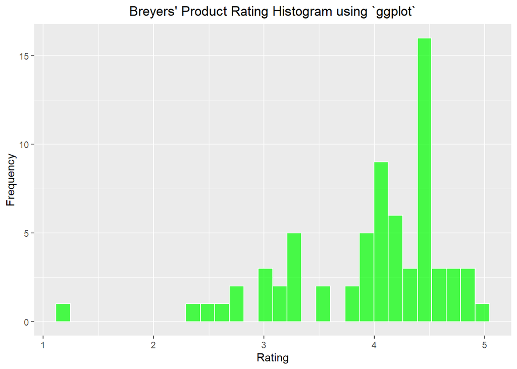

```r
breyers_data <- subset(products, Brand == "breyers")

breycol <- brandcolordf$color[brandcolordf$brand=="breyers"]
breyfill <-brandcolordf$fill[brandcolordf$brand=="breyers"]

ggplot(breyers_data, aes(Rating)) +
  geom_histogram(col=breycol, fill=breyfill, alpha=0.7) +
  labs(x="Rating", y="Frequency") +
  labs(title="Breyers' Product Rating Histogram using `ggplot`") +
  theme(plot.title = element_text(hjust = 0.5))
```

```r
mean.breyratings <- mean(breyers_data$Rating)
sd.breyratings <- sd(breyers_data$Rating)
```

From the graph, the breyers data is similar to the histogram of Ben & Jerry’s and the combined dataset. The graph also displays a left-skewed distribution. The mean of the data above is 3.962 and the standard deviation is 0.711

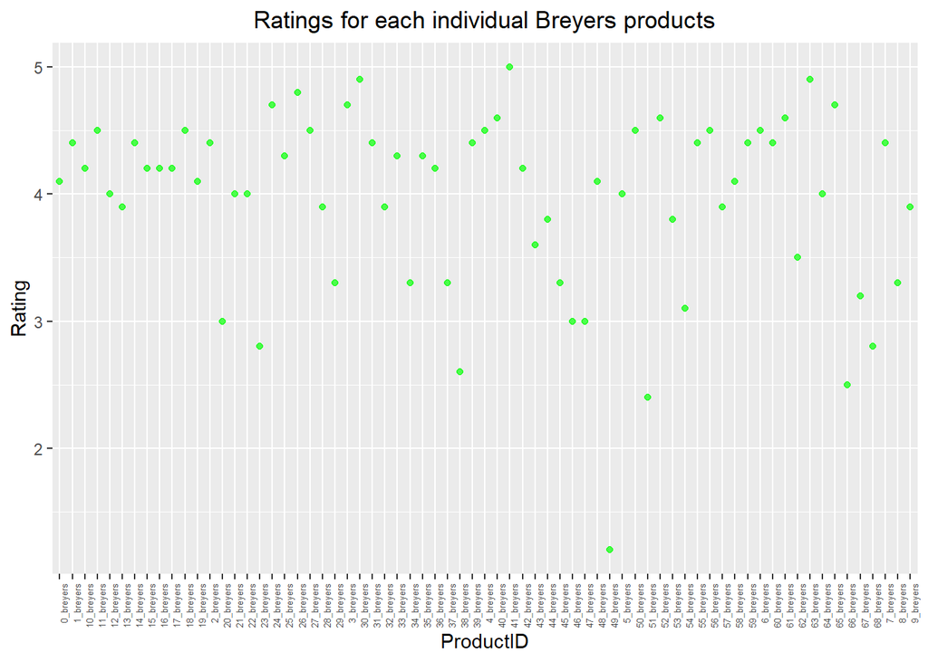

```r
#color and fill are inverted here for readability
ggplot(breyers_data, aes(x=ProductID, y=Rating)) +
  geom_point(col=breyfill, fill=breycol, alpha=0.7) +
  labs(x="ProductID", y='Rating') +
  labs(title="Ratings for each individual Breyers products") +
  theme(axis.text.x = element_text(angle=90, hjust=1, size = 5)) +
  theme(plot.title = element_text(hjust = 0.5))
```

```r
# Finding the highest rated products
max_rating_index <- which(breyers_data$Rating == max(breyers_data$Rating))
max_productname <- breyers_data$ProductName[max_rating_index]

# Finding the lowest rated products
min_rating_index <- which(breyers_data$Rating == min(hd_data$Rating))
min_productname <- breyers_data$ProductName[min_rating_index]
```

Based from the graph, the highest rated Breyers product: OREO® Snack Cups 10ct

```
## [1] "Bought some of each flavor and stuck them in the freezer at work so anyone still in the office could have a treat with minimal communal handling. Lovely and Delicious."
## [2] "My favorite ice cream in portion sizes. Great idea. Please do mint chip."
```

Above are the two reviews of Breyers’ Oreo Snack Cups 10ct. Both reviews praise on how the ice cream is portioned out.

Based from the graph, the lowest rated Breyers product: Layered Dessert S’mores

```
## [1] "Missed the flavor of s’more. No marshmallow flavor, chocolate very light- the graham crumb bites were good, overall very disappointed as this was really a splurge"
## [2] "Based on previous reviews, it seems a few didn't like it, but I personally did. It is actually one of my new favorite flavors so far. Have been trying to find a smores ice cream that was actually good since my favorite smores ice cream were discontinued by another company a few years ago. Ne…
## [3] "S’mores flavored is cream is one of my favorites. Brewers usually has great quality and therefore yummy ice cream so I was excited to see this flavor in the store. This version is very disappointing. The marshmallows are really gross-weird textures-almost like stale hard mini marshmallows yo…
## [4] "I was really looking forward to this ice cream but its actually gross. It tastes like really strong cinnamon and cardboard. :("
## [5] "I love ice cream and saw this at the store so I figured I would try S'mores along with the Peach cobbler. I tried the S'mores first, along with my family, and it was awful. taste nothing like S'mores. The graham cracker was grainy, marshmallows tasted like vanilla frosting. Will NOT buy agai…
## [6] "Marshmallows are chalky while the graham cracker piece does leave a lot to be desired. Please try again I would gladly give it another try when the contents are changed."
```

Above are the first 6 reviews of Breyers’ Layered Dessert S’mores. Customers complained on how the product does not taste like s’mores. Specifically, the marshmellows and graham crackers was either lacking or tasted awful, and the overall taste of what customers expected for s’mores did not meet their expectations. Though some customers actually like the product.

#### Measures of Central Tendency

With the Breyers data subset, we will calculate the mean, median, and mode for this dataset.

- `Mean`: 3.962
- `Median`: 4.2
- `Mode`: 4.4

The measures of central tendency show that the average rating is 3.962, the median rating is 4.2, with a score of 4.4 appearing most often. Again like the other brands, these values prove that the data displays a left skewed distribution.

#### Measures of Variation

With the Breyers data subset, we will calculate the range, mean deviation, standard deviation, and variance.

- `Range`: 1.2, 5
- `Mean Deviation`: 0.544
- `Standard Deviation`: 0.711
- `Variance`: 0.506

With the Breyers dataset, the data ranges 3.8 data points from the lowest point to the highest point. The mean deviation here shows us that on average, each value in the dataset is about 0.544 points away from the mean. The standard deviation shows us that the data is dispersed 0.711 points in relation to the mean. The variance shows that each data point is about 0.506 points away from the mean and other data points in the dataset.

## EDA Conclusion

Based on the results of the EDA testing, we can conclude for each of the following for each brand.

- `Ben & Jerry's`: The average of the dataset is 4.332, with a standard deviation of 0.6 above and below the mean. There are two products that received the highest rating: Chocolate Peanut Butter Split and Ice Cream Sammie, and one product that received the lowest ranking, Chocolate Chip Cookie Dough Core.
- `Häagen-Dazs`: The average of the dataset is 4.307, with a standard deviation of 0.597. There are five products that received the highest ranking, Chocolate Fudge Non-Dairy Bar, Honey Salted Caramel Almond Ice Cream, Peppermint Bark Ice Cream, Peppermint Bark Ice Cream Bar, and Vanilla Caramel White Chocolate Trio Crispy Layers, and one product that received the lowest ranking, Vanilla Milk Chocolate Almond Ice Cream Bar.
- `Talenti`: The average of the dataset is 4.356, with a standard deviation of 0.387 above and below the mean. There are four products that received the highest ranking: Belgian Chocolate Gelato, Caramel Apple Pie Gelato, Coconut Almond Chocolate Gelato, and Organic Oak-Aged Vanilla Gelato; and there is one product that received the lowest ranking: Chocolate Chip Cookie Dough Gelato.
- `Breyers`: The average of the dataset is 3.962, with a standard deviation of 0.711 above and below the mean. There is one product that has received the highest ranking: Oreo Snack Cups 10ct; and one product has received the lowest rating: Layered Dessert S’mores.

# Hypothesis Testing

### Ingredient Indicators

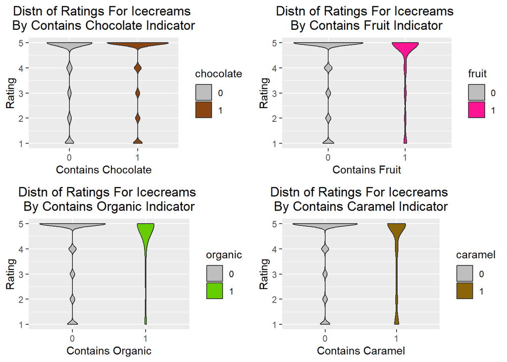

```r
chocvio <- ggplot(productreview,aes(HAS_CHOCOLATE,Stars)) +
  geom_violin(aes(fill=HAS_CHOCOLATE)) +
  scale_fill_manual(values=c("grey","chocolate4")) +
    labs(title="Distn of Ratings For Icecreams \nBy Contains Chocolate Indicator",
       x="Contains Chocolate",
       y="Rating") +
    theme(plot.title = element_text(hjust = 0.5)) +
    guides(fill=guide_legend(title="chocolate"))

fruitvio <- ggplot(productreview,aes(HAS_FRUIT,Stars)) +
  geom_violin(aes(fill=HAS_FRUIT)) +
  scale_fill_manual(values=c("grey","deeppink")) +
    labs(title="Distn of Ratings For Icecreams \nBy Contains Fruit Indicator",
       x="Contains Fruit",
       y="Rating") +
    theme(plot.title = element_text(hjust = 0.5)) +
    guides(fill=guide_legend(title="fruit"))

organicvio <- ggplot(productreview,aes(HAS_ORGANIC,Stars)) +
  geom_violin(aes(fill=HAS_ORGANIC)) +
  scale_fill_manual(values=c("grey","chartreuse3")) +
    labs(title="Distn of Ratings For Icecreams \nBy Contains Organic Indicator",
       x="Contains Organic",
       y="Rating") +
    theme(plot.title = element_text(hjust = 0.5)) +
    guides(fill=guide_legend(title="organic"))

caramelvio <- ggplot(productreview,aes(HAS_CARAMEL,Stars)) +
  geom_violin(aes(fill=HAS_CARAMEL)) +
  scale_fill_manual(values=c("grey","darkgoldenrod4")) +
    labs(title="Distn of Ratings For Icecreams \nBy Contains Caramel Indicator",
       x="Contains Caramel",
       y="Rating") +
    theme(plot.title = element_text(hjust = 0.5)) +
    guides(fill=guide_legend(title="caramel"))

grid.arrange(chocvio, fruitvio,
             organicvio, caramelvio,
             nrow=2)
```

```r
choccounts <- count(productreview, HAS_CHOCOLATE)
fruitcounts <- count(productreview, HAS_FRUIT)
organiccounts <- count(productreview, HAS_ORGANIC)
caramelcounts <- count(productreview, HAS_CARAMEL)
```

Above we are able to observe the distributions of product reviews grouped by the ingredient indicators that were prepared earlier.

1. We can see that the icecream reviews seem to have similarly shaped distributions of ratings for icecreams that do and don’t contain chocolate. The same cannot be said for reviews for the other ingredient indicators.
2. Reviews of icecreams containing Fruit, Organic, and Caramel ingredients represent relatively small proportions of the total icecream reviews as is evinced by their smaller violin charts.
- `Choc` - 0: 4591 / 1: 17083
- `Fruit` - 0: 20131 / 1: 1543
- `Organic` - 0: 21601 / 1: 73
- `Caramel` - 0: 19973 / 1: 1701

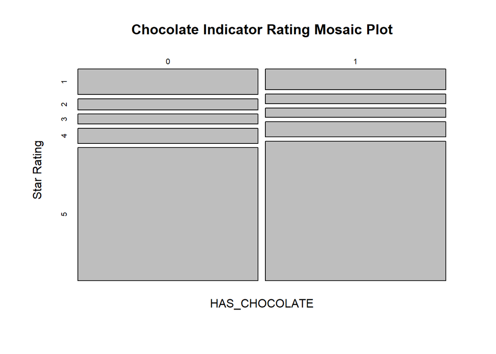

```r
choc_contingency_table<-table(productreview$HAS_CHOCOLATE,productreview$Stars, dnn=c("HAS_CHOCOLATE", "Star Rating"))
chocmoplot<- mosaicplot(prop.table(choc_contingency_table,margin=1),
                        main="Chocolate Indicator Rating Mosaic Plot")
```

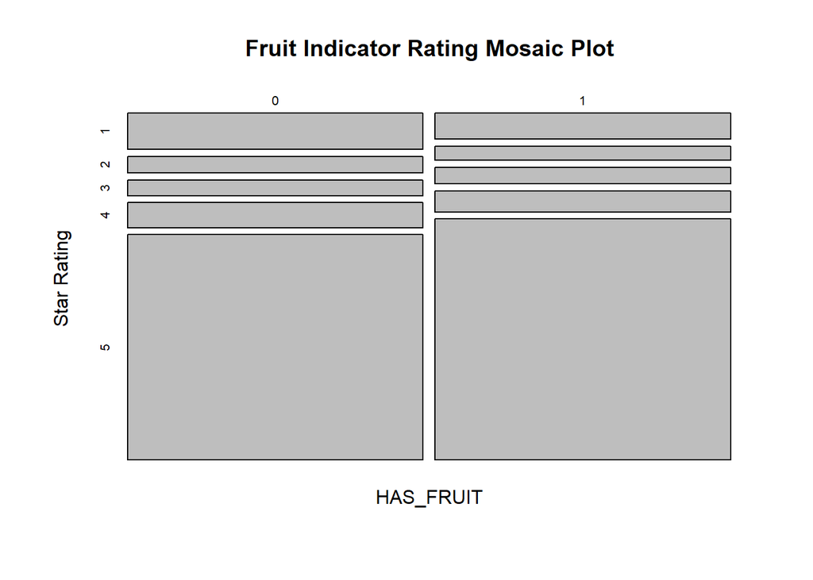

```r
fruit_contingency_table<-table(productreview$HAS_FRUIT,productreview$Stars, dnn=c("HAS_FRUIT", "Star Rating"))
fruitmoplot<- mosaicplot(prop.table(fruit_contingency_table,margin=1),
                        main="Fruit Indicator Rating Mosaic Plot")
```

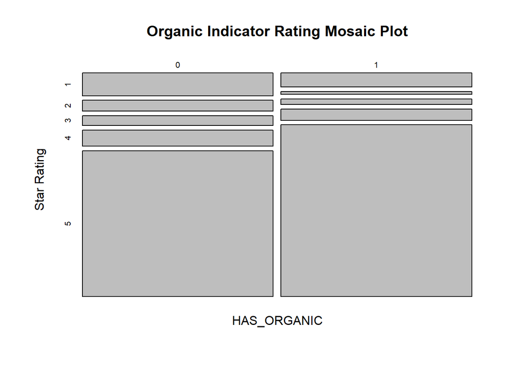

```r
organic_contingency_table<-table(productreview$HAS_ORGANIC,productreview$Stars, dnn=c("HAS_ORGANIC", "Star Rating"))
organicmoplot<- mosaicplot(prop.table(organic_contingency_table,margin=1),
                        main="Organic Indicator Rating Mosaic Plot")
```

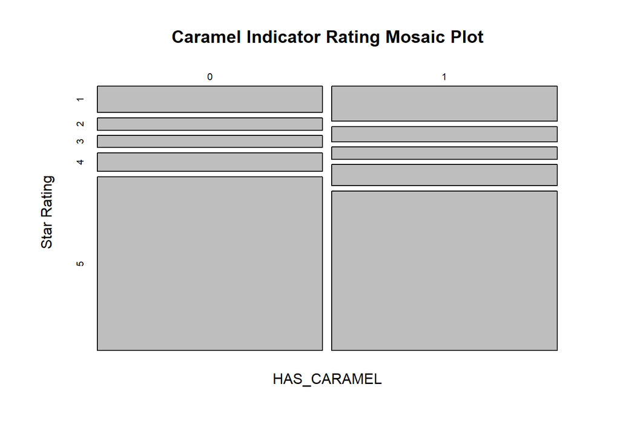

```r
caramel_contingency_table<-table(productreview$HAS_CARAMEL,productreview$Stars, dnn=c("HAS_CARAMEL", "Star Rating"))
caramelmoplot<- mosaicplot(prop.table(caramel_contingency_table,margin=1),
                        main="Caramel Indicator Rating Mosaic Plot")
```

Above are mosaic plots for proportions of star ratings for each ingredient indicator in the product-review data. These plots yield some interesting insights into proportions of ratings for groups which contain or do not contain certain ingredients.

These apparent differences warrant additional statistical testing.

```r
choc_chisq <- chisq.test(choc_contingency_table)
fruit_chisq <- chisq.test(fruit_contingency_table)
org_chisq <- chisq.test(organic_contingency_table)
caramel_chisq <-chisq.test(caramel_contingency_table)
```

We review the above results from the Chi-Squared independence tests for our ingredient indicators:

- **HAS_CHOCOLATE** - The Chi-Squared test yields a p-value of 6.49^{-6}, thus with 95% confidence we reject the null hypothesis that star rating is independent of `chocolate` ingredient content in the icecreams.
- **HAS_FRUIT** - The Chi-Squared test yields a p-value of 1.122^{-4}, thus with 95% confidence we reject the null hypothesis that star rating is independent of `fruit` ingredient content in the icecreams.
- **HAS_ORGANIC** - The Chi-Squared test yields a p-value of 0.192, thus with 95% confidence we fail to reject the null hypothesis that star rating is independent of `organic` ingredient content in the icecreams.
- **HAS_CARAMEL** - The Chi-Squared test yields a p-value of 1.122^{-4}, thus with 95% confidence we reject the null hypothesis that star rating is independent of `caramel` ingredient content in the icecreams.

With these results in mind we can say with high confidence that for the above ingredient groupings star rating is not independent of ingredient content (organic ingredients being a notable exception)

# References

About Breyers History. (N.d.). Breyers. Retrieved March 12, 2024, from https://www.breyers.com/us/en/about.html

About Us. (N.d.). Häagen Dazs. Retrieved March 12, 2024, from https://www.icecream.com/us/en/brands/haagen-dazs/about

Our Process. (N.d.). Talenti. Retrieved March 12, 2024, from https://www.talentigelato.com/us/en/our-process.html

Our Values, Activism, and Mission. (N.d.). Ben & Jerry’s. Retrieved March 12, 2024, from https://www.benjerry.com/values

Pond, T. (2020, Sept). Ice Cream Dataset. Kaggle. Retrieved March 11, 2024, from https://www.kaggle.com/datasets/tysonpo/ice-cream-dataset/data